# Checkpoint2-Problema3

19 de agosto de 2016

# Analisando padrões em emendas parlamentares

## Método de redução de dimensionalidade

Prosseguindo o que foi feito em análises anteriores, o objetivo desta análise é encontrar e evidênciar padrões no valor liberado pelos deputados brasileiros por meio de emendas parlamentares. Agora, ao contário da análise anterior que utilizou hierarquical clustering e knn, os métodos utilizados podem ser PCA e T-SNE. Foram analisados dados de emendas parlamentares referentes aos anos 2015 e 2016, que equivalem aos dois primeiros anos da 55ª legislatura da Câmara Federal. Tais dados limitaram-se somente àqueles destinados aos Ministérios da Integração Nacional, Agricultura, Desenv. Social, Cultura e Esporte.

Dessa vez, o alvo do agrupamento são os partidos políticos. Haveria algum padrão entre os valores liberads por cada partido?

Para começar, foi testado o método de redução de dimensionalidade PCA (PRINCIPAL COMPONENT ANALYSIS). Seus resultados não foram muito animadores, visto que não foi possível observar claramente os grupos de partidos.

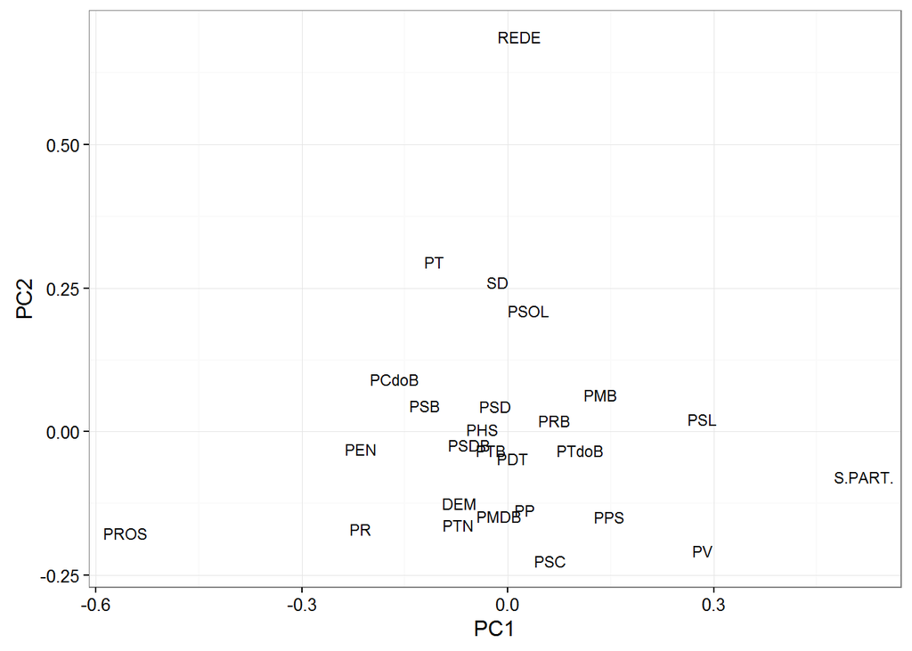

A segunda alternativa foi utilizar o método de redução TSNE (T-Distributed Stochastic Neighbor Embedding). Aqui, os resultados foram mais animadores. Ajustando o nível de embaraço (perplexity), foi possível observar que os melhores resultados são obtidos ajustando tal nível ao valor 3. Feito isso, foi possível observar os grupos de Partidos, que podem ser vistos no gráfico abaixo.

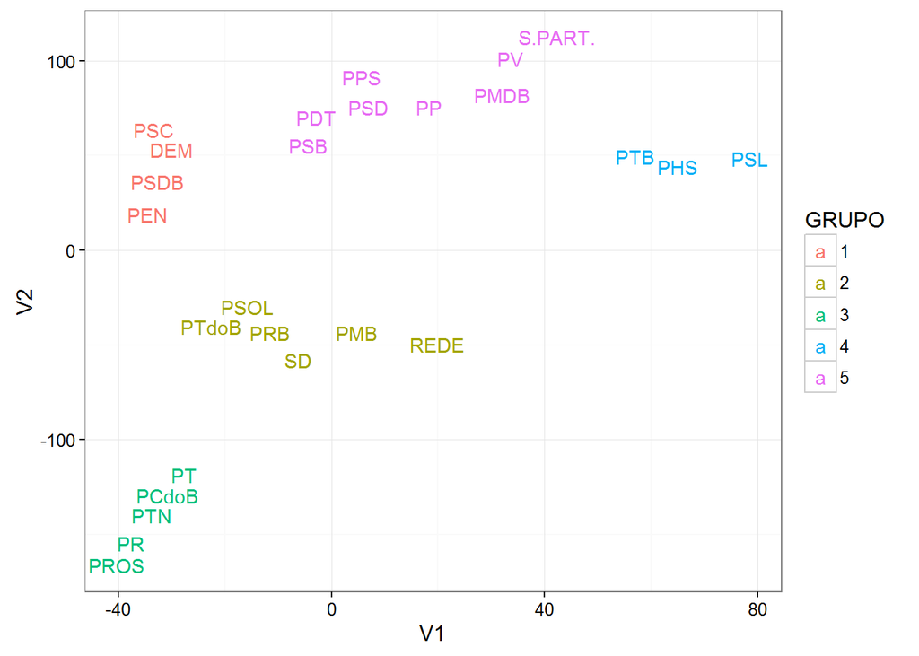

Uma visão mais aprofundada de tais grupos possibilita ver as principais diferenças entre eles.

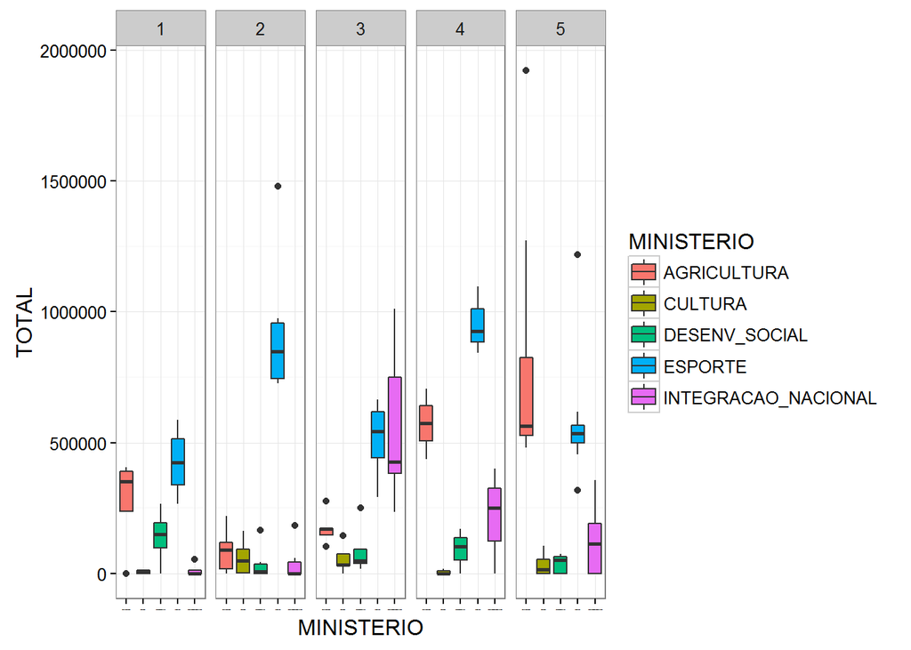

Ao análisar os boxplot podemos ver que no grupo 2, por exemplo, os parlamentares destinam grande parte da verba para o esporte. Os parlamentares desse grupo são, ainda, os que mais investem em cultura. Nos grupos 1 e 4, o esporte também é o principal destino das verbas, mas aqui os deputados também destinam bastante verba para a agricultura. A principal diferença entre os dois grupos é o total repassado. A agricultura é a principal destinação da verba das emendas aprovadas pelos deputados do grupo 5. Foi uma surpresa ver o Partido Verde incluso nesse grupo, já que uma das bandeiras do partido é o ambientalismo. Por fim, temos o grupo 3. Os deputados deste grupo destinam a maior parte das verbas para o esporte e a integração nacional.